# Project1-Naive - 2 - Analysis Update

## Dat 402 Project 1: Lillian Tretheway

### Predicting Obesity

Obesity is one of the largest preventable diseases in the United States and can cause many other issues such as cardiovascular diseases and cancer. There are many attributes that increase a person's chance of being obese such as family history and diet. We want to predict if someone will be obese based off of the list of attributes in the study because obesity is a common and detrimental disease. Being able to predict whether someone is high-risk for obesity and identify what factors are most influential can help people make lifestyle changes and improve their health.

```python
import csv
import pandas as pd
import numpy as np
import seaborn as sns
import matplotlib.pyplot as plt
from sklearn.model_selection import train_test_split, GridSearchCV, cross_val_score
from sklearn.preprocessing import StandardScaler
from sklearn.ensemble import RandomForestClassifier
from sklearn.linear_model import LogisticRegression
from sklearn.naive_bayes import MultinomialNB
from sklearn.preprocessing import OneHotEncoder
from sklearn.preprocessing import OrdinalEncoder
from sklearn.metrics import accuracy_score, classification_report, confusion_matrix
```

### Import Dataset

##### https://archive.ics.uci.edu/dataset/544/estimation+of+obesity+levels+based+on+eating+habits+and+physical+condition

There are 16 variables in this dataset consisting of different variable types such as binary, contiuous, categorical, and integer.

Independent variables: The first feature is gender which is labeled as male/female. Age, Height, and Weight are continous variables that are set to the individual's value for each variable. Familiy_history_with_overweigh is a yes/no variable that reflects whether or not the individual has a family member who suffers from obesity. FAVC is the answer to the yes/no question of "Do you eat high caloric food frequently?" and FAVC is the answer to the question "Do you usually eat vegetables in your meals?". The variable NCP is the number of meals eaten per day and CAEC is if the individual eats in between meals. SMOKE is the binary variable of whether or not the individual smokes. CH20 is how much water drinken per day, SCC is whether or not the individual monitors calories per day, and FAF is how often the individual participates in physical activity. TUE is how often the individual uses electronics such as video games, television, etc. CALC is how often the individual drinks alcohol and MTRANS is the form of transportation that the individual normally uses.

Dependent variabels: NObeyesdad is the categorical variable of all the different class ranges of obesity.

```python
obesity = pd.read_csv('ObesityDataSet_raw_and_data_sinthetic.csv')
ob = obesity
obesity.head()
```

|  | Gender | Age | Height | Weight | family_history_with_overweight | FAVC | FCVC | NCP | CAEC | SMOKE | CH2O | SCC | FAF | TUE | CALC | MTRANS | NObeyesdad |
| --- | --- | --- | --- | --- | --- | --- | --- | --- | --- | --- | --- | --- | --- | --- | --- | --- | --- |
| 0 | Female | 21.0 | 1.62 | 64.0 | yes | no | 2.0 | 3.0 | Sometimes | no | 2.0 | no | 0.0 | 1.0 | no | Public_Transportation | Normal_Weight |
| 1 | Female | 21.0 | 1.52 | 56.0 | yes | no | 3.0 | 3.0 | Sometimes | yes | 3.0 | yes | 3.0 | 0.0 | Sometimes | Public_Transportation | Normal_Weight |
| 2 | Male | 23.0 | 1.80 | 77.0 | yes | no | 2.0 | 3.0 | Sometimes | no | 2.0 | no | 2.0 | 1.0 | Frequently | Public_Transportation | Normal_Weight |
| 3 | Male | 27.0 | 1.80 | 87.0 | no | no | 3.0 | 3.0 | Sometimes | no | 2.0 | no | 2.0 | 0.0 | Frequently | Walking | Overweight_Level_I |
| 4 | Male | 22.0 | 1.78 | 89.8 | no | no | 2.0 | 1.0 | Sometimes | no | 2.0 | no | 0.0 | 0.0 | Sometimes | Public_Transportation | Overweight_Level_II |

```python
obesity.shape
```

```
(2111, 17)
```

### Data Munging/Cleaning

#### Removing weight since it is obviously highly correlated with obesity

Columns were renamed to clearer feature names for the rest of the analysis.

```python
obesity.drop('Weight',axis=1,inplace=True)
new_col_names = ['Gender','Age','Height','Fam_Hist','High_Cal_Freq','Veg_Freq','Meals_PDay','Snacks','Smoke','Water_PDay','Cal_Count','Exercise_Freq','Tech_Time','Alcohol','Transport_Type','Obesity_Level']
obesity.columns = new_col_names
obesity.head()
```

|  | Gender | Age | Height | Fam_Hist | High_Cal_Freq | Veg_Freq | Meals_PDay | Snacks | Smoke | Water_PDay | Cal_Count | Exercise_Freq | Tech_Time | Alcohol | Transport_Type | Obesity_Level |
| --- | --- | --- | --- | --- | --- | --- | --- | --- | --- | --- | --- | --- | --- | --- | --- | --- |
| 0 | Female | 21.0 | 1.62 | yes | no | 2.0 | 3.0 | Sometimes | no | 2.0 | no | 0.0 | 1.0 | no | Public_Transportation | Normal_Weight |
| 1 | Female | 21.0 | 1.52 | yes | no | 3.0 | 3.0 | Sometimes | yes | 3.0 | yes | 3.0 | 0.0 | Sometimes | Public_Transportation | Normal_Weight |
| 2 | Male | 23.0 | 1.80 | yes | no | 2.0 | 3.0 | Sometimes | no | 2.0 | no | 2.0 | 1.0 | Frequently | Public_Transportation | Normal_Weight |
| 3 | Male | 27.0 | 1.80 | no | no | 3.0 | 3.0 | Sometimes | no | 2.0 | no | 2.0 | 0.0 | Frequently | Walking | Overweight_Level_I |
| 4 | Male | 22.0 | 1.78 | no | no | 2.0 | 1.0 | Sometimes | no | 2.0 | no | 0.0 | 0.0 | Sometimes | Public_Transportation | Overweight_Level_II |

```python
obesity.isna().sum()
```

```
Gender            0
Age               0
Height            0
Fam_Hist          0
High_Cal_Freq     0
Veg_Freq          0
Meals_PDay        0
Snacks            0
Smoke             0
Water_PDay        0
Cal_Count         0
Exercise_Freq     0
Tech_Time         0
Alcohol           0
Transport_Type    0
Obesity_Level     0
dtype: int64
```

It is essential to make sure there are no null or missing values because the rest of the analysis will not work. If there were missing values, we would either drop them or replace them.

```python
obesity.describe()
```

|  | Age | Height | Veg_Freq | Meals_PDay | Water_PDay | Exercise_Freq | Tech_Time |
| --- | --- | --- | --- | --- | --- | --- | --- |
| count | 2111.000000 | 2111.000000 | 2111.000000 | 2111.000000 | 2111.000000 | 2111.000000 | 2111.000000 |
| mean | 24.312600 | 1.701677 | 2.419043 | 2.685628 | 2.008011 | 1.010298 | 0.657866 |
| std | 6.345968 | 0.093305 | 0.533927 | 0.778039 | 0.612953 | 0.850592 | 0.608927 |
| min | 14.000000 | 1.450000 | 1.000000 | 1.000000 | 1.000000 | 0.000000 | 0.000000 |
| 25% | 19.947192 | 1.630000 | 2.000000 | 2.658738 | 1.584812 | 0.124505 | 0.000000 |
| 50% | 22.777890 | 1.700499 | 2.385502 | 3.000000 | 2.000000 | 1.000000 | 0.625350 |
| 75% | 26.000000 | 1.768464 | 3.000000 | 3.000000 | 2.477420 | 1.666678 | 1.000000 |
| max | 61.000000 | 1.980000 | 3.000000 | 4.000000 | 3.000000 | 3.000000 | 2.000000 |

This table shows the different calculations such as mean, max, and percentiles for the variables. For example, we can see that the mean age of the dataset is 24.3 and the maximum meals per day is 4 meals. This is discussed more in the histogram sections

```python
obesity.dtypes
```

```
Gender             object
Age               float64
Height            float64
Fam_Hist           object
High_Cal_Freq      object
Veg_Freq          float64
Meals_PDay        float64
Snacks             object
Smoke              object
Water_PDay        float64
Cal_Count          object
Exercise_Freq     float64
Tech_Time         float64
Alcohol            object
Transport_Type     object
Obesity_Level      object
dtype: object
```

### Data Exploration

```
array([[<AxesSubplot:title={'center':'Age'}>,
        <AxesSubplot:title={'center':'Height'}>,
        <AxesSubplot:title={'center':'Veg_Freq'}>],
       [<AxesSubplot:title={'center':'Meals_PDay'}>,
        <AxesSubplot:title={'center':'Water_PDay'}>,
        <AxesSubplot:title={'center':'Exercise_Freq'}>],
       [<AxesSubplot:title={'center':'Tech_Time'}>, <AxesSubplot:>,
        <AxesSubplot:>]], dtype=object)
```

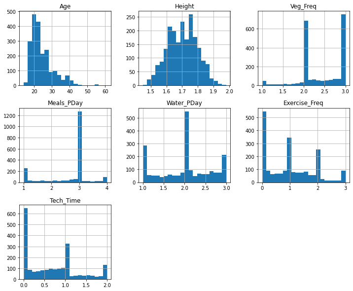

```python
obesity.hist(bins=20, figsize=(12,10))
```

Veg_Freq: The vegetable frequency is left skewed. The most common and highest frequency of individuals eating breakfast is 3. The next most common answer is 2 and the lowest frequency reported is 1.

Meals_PDay: The most common number of meals per day among these indivudals is 3. 1 meal per day is the next most common answer followed by 4 meals per day.

Water_Pday: Most individuals in this sample drink 2 waters per day. The second most common answer is 1 per day and the next most common is 3 per day.

Exercise_Freq: The exercise frequency's most common answer is 0 physical activity and the following answers (1, 2, 3) get smaller and smaller.

Tech_Time: Majority of the answers for tech time is between 0 and 1, with some responses being between 1 and 2. The most common response is 0 hours of tech time.

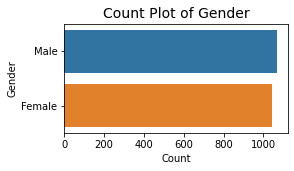

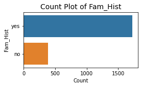

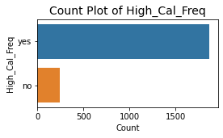

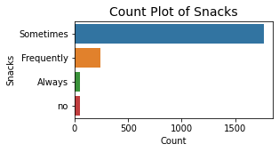

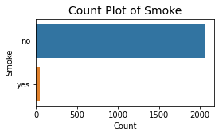

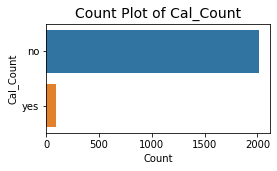

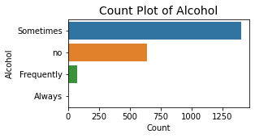

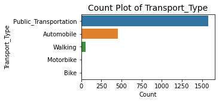

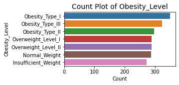

```python
for col in obesity.select_dtypes(include='object').columns:
    plt.figure(figsize=(4,2))
    sns.countplot(y=col, data=obesity, order=obesity[col].value_counts().index)  # y=col for horizontal bars
    plt.title(f'Count Plot of {col}', fontsize=14)
    plt.xlabel('Count')
    plt.ylabel(col)
    plt.show()
```

Gender: The distribution of males versus females is fairly even with the number of males being slightly higher.

Fam_Hist: There are many more individuals who have a family history of obesity versus those who do not.

High_Cal_Freq: There is a significantly higher number of individuals who frequently consume high caloric foods.

Snacks: The most common answer to the question regarding eating between meals is "sometimes" with "frequently" being the second highest

Smoke: Majority of the individuals in this study answered No to smoking while only a few said they smoke.

Cal_Count: Majority of the individuals do not monitor their calories.

Alcohol: The most common answer to the frequency of alcohol consumtion is "Sometimes" with "no" being the second highest answer.

Transport_Type: The most common type of transportation is public transportation with automobile being the second most common answer.

### Correlation

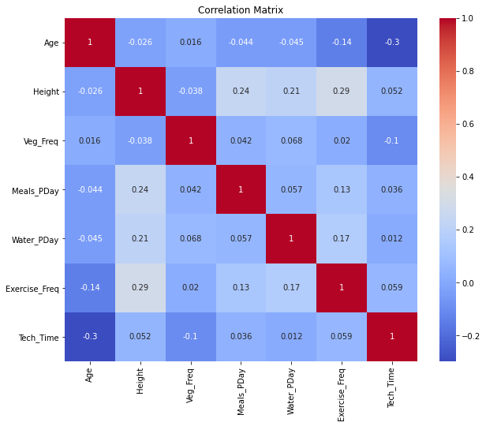

```python
correlation_matrix = obesity.corr()

plt.figure(figsize=(10, 8))
sns.heatmap(correlation_matrix, annot=True, cmap='coolwarm')
plt.title('Correlation Matrix')
plt.show()
```

This is the correlation matrix between all of the independent variables. Age and tech_time are one of the most correlated features with a correlation value of -0.3. This means that these two variables are somewhat negatively related. Height and exersice_freq are slightly positviely correlated with a value of 0.29. Height and Meals_Pday as well as Height and Water_Pday are also slightly positively correlated with values of 0.24 and 0.21, respectively.

There are no variables that are too correlated with each other which leads us to believe that multicollinearity will not be a large issue during our logistic regression. Multicollinearity is when some of the independent variables are highly correlated to eachother. A general correlation value to show that there is multicollinearity is if the correlation coefficient is greater than 0.8 which we do not have in our results.

### Encoding Training Data and Continued Analysis

Several predictors are based on categorical data, so encoding some variables was necessary.

#### OrdinalEncoder

The target variable was dropped for the remainder of analysis for organizational purposes.

```python
obesity_train = obesity.drop('Obesity_Level', axis=1)
```

```python
columns_to_encode = ['Snacks', 'Alcohol']
order = ['no', 'Sometimes', 'Frequently', 'Always']

encoder = OrdinalEncoder(categories=[order, order])
obesity_train[columns_to_encode] = encoder.fit_transform(obesity_train[columns_to_encode])
```

After encoding the columns using OrdinalEndoer, the DataFrame below now has numeric values for 'Snacks' and 'Alcohol' columns.

```python
obesity_train.head()
```

|  | Gender | Age | Height | Fam_Hist | High_Cal_Freq | Veg_Freq | Meals_PDay | Snacks | Smoke | Water_PDay | Cal_Count | Exercise_Freq | Tech_Time | Alcohol | Transport_Type |
| --- | --- | --- | --- | --- | --- | --- | --- | --- | --- | --- | --- | --- | --- | --- | --- |
| 0 | Female | 21.0 | 1.62 | yes | no | 2.0 | 3.0 | 1.0 | no | 2.0 | no | 0.0 | 1.0 | 0.0 | Public_Transportation |
| 1 | Female | 21.0 | 1.52 | yes | no | 3.0 | 3.0 | 1.0 | yes | 3.0 | yes | 3.0 | 0.0 | 1.0 | Public_Transportation |
| 2 | Male | 23.0 | 1.80 | yes | no | 2.0 | 3.0 | 1.0 | no | 2.0 | no | 2.0 | 1.0 | 2.0 | Public_Transportation |
| 3 | Male | 27.0 | 1.80 | no | no | 3.0 | 3.0 | 1.0 | no | 2.0 | no | 2.0 | 0.0 | 2.0 | Walking |
| 4 | Male | 22.0 | 1.78 | no | no | 2.0 | 1.0 | 1.0 | no | 2.0 | no | 0.0 | 0.0 | 1.0 | Public_Transportation |

#### Dummy Variables:

Dummy variables were used to encode other categorical data. Dummy variables create binary columns for each unique categorical instances in a column. In this case, the drop_first function was used, so the number of columns added in place of the original columns is n-1, where n is the number of unique categorical instances. This approach was used for all other categorical variables that have no inherant rank, such as 'Yes' and 'No' or 'Female' and 'Male'.

After encoding with dummy variables, column names change, some new columns are present, and previously categorical data is stored in a binary format.

```python
# encode nominal categorical variables with dummy variables and check
obesity_train = pd.get_dummies(obesity_train, drop_first=True)
obesity_train.head()
```

|  | Age | Height | Veg_Freq | Meals_PDay | Snacks | Water_PDay | Exercise_Freq | Tech_Time | Alcohol | Gender_Male | Fam_Hist_yes | High_Cal_Freq_yes | Smoke_yes | Cal_Count_yes | Transport_Type_Bike | Transport_Type_Motorbike | Transport_Type_Public_Transportation | Transport_Type_Walking |
| --- | --- | --- | --- | --- | --- | --- | --- | --- | --- | --- | --- | --- | --- | --- | --- | --- | --- | --- |
| 0 | 21.0 | 1.62 | 2.0 | 3.0 | 1.0 | 2.0 | 0.0 | 1.0 | 0.0 | 0 | 1 | 0 | 0 | 0 | 0 | 0 | 1 | 0 |
| 1 | 21.0 | 1.52 | 3.0 | 3.0 | 1.0 | 3.0 | 3.0 | 0.0 | 1.0 | 0 | 1 | 0 | 1 | 1 | 0 | 0 | 1 | 0 |
| 2 | 23.0 | 1.80 | 2.0 | 3.0 | 1.0 | 2.0 | 2.0 | 1.0 | 2.0 | 1 | 1 | 0 | 0 | 0 | 0 | 0 | 1 | 0 |
| 3 | 27.0 | 1.80 | 3.0 | 3.0 | 1.0 | 2.0 | 2.0 | 0.0 | 2.0 | 1 | 0 | 0 | 0 | 0 | 0 | 0 | 0 | 1 |
| 4 | 22.0 | 1.78 | 2.0 | 1.0 | 1.0 | 2.0 | 0.0 | 0.0 | 1.0 | 1 | 0 | 0 | 0 | 0 | 0 | 0 | 1 | 0 |

### Correlation matrix of all variables

Now that we have all of the variables, we can do another correlation matrix with all of our variables. To check for multicolinearity, we want to make sure that no values are near or greater than 0.8. Since our highest correlation coefficient is 0.62 for Height and Gender_Male (where 0 is female and 1 is male), there is a very low chance of having multicollinearity.

Height and Gender_Male have a somewhat positive correlation of 0.62. This makes sense because men tend to be taller than females. It appears that Height tends to have the most correlations between other variables such as the variables stated in the previous correlation matrix. Height is also slightly positively correlated to Fam_Hist_yes with a coefficient of 0.25. Age is somewhat negatively correlated to Transport_Type_Public_Transport with a coefficient of -0.55. Age and tech_time are slightly negatively correlated with a coefficient of -0.3 which makes sense because younger people are more likely to use more technology such as video games.

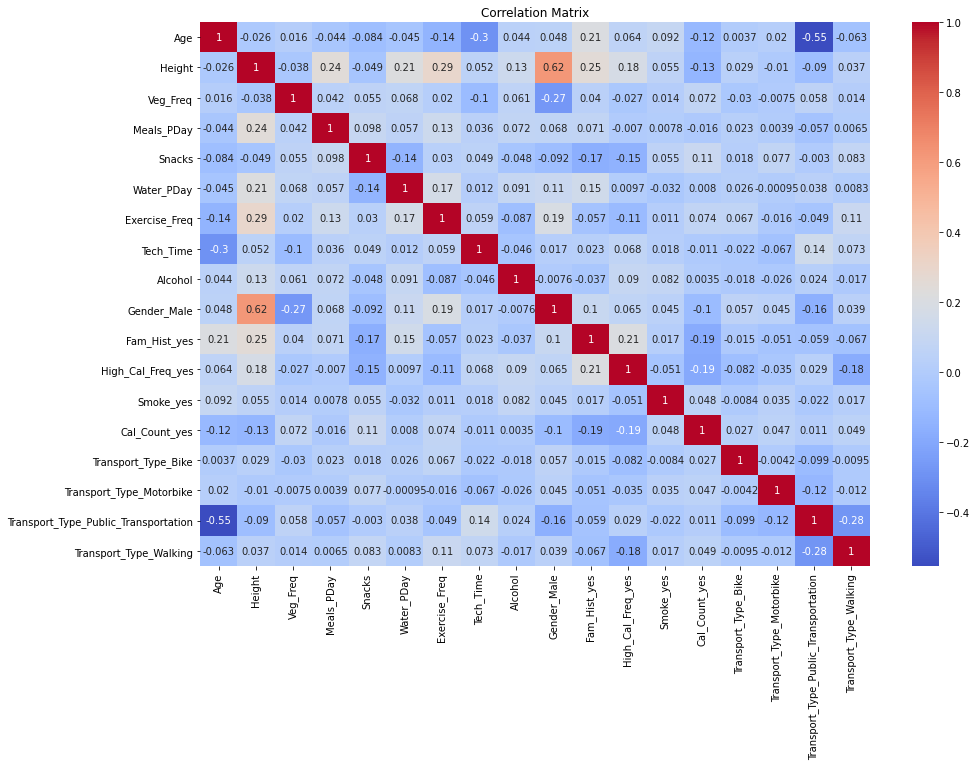

```python
# correlation matrix of all variables
correlation_matrix = obesity_train.corr()

plt.figure(figsize=(15, 10))
sns.heatmap(correlation_matrix, annot=True, cmap='coolwarm')
plt.title('Correlation Matrix')
plt.show()
```

To ensure multicollinearity won't be a signficant issue, the VIF was checked for each variable. VIF stands for "Variance Inflation Factorr" and quantified how much of the variance of regression coefficient is inflated due to multicollienarity. VIF values greater than 5 indicate that may be some effect on model performance due to redundant information. VIF values greater than 10 indicate severe mutlicollienarity and should be dealt with accordingly. Below shows that no variables are of concern for multicollinearity.

```python
import pandas as pd
import statsmodels.api as sm
from statsmodels.stats.outliers_influence import variance_inflation_factor

# Ensure your DataFrame is numeric
obesity_train_numeric = obesity_train.apply(pd.to_numeric)

# Add a constant column for the intercept
obesity_train_vif = sm.add_constant(obesity_train_numeric)

# Calculate VIF for each predictor variable (skipping the constant column)
vif_data = pd.DataFrame()
vif_data["Feature"] = obesity_train_vif.columns[1:]  # Skip the constant column
vif_data["VIF"] = [variance_inflation_factor(obesity_train_vif.values, i)
                   for i in range(1, obesity_train_vif.shape[1])]  # Start from index 1

print(vif_data)
```

```
                                 Feature       VIF
0                                    Age  1.895844
1                                 Height  2.179839
2                               Veg_Freq  1.152649
3                             Meals_PDay  1.107511
4                                 Snacks  1.110213
5                             Water_PDay  1.121602
6                          Exercise_Freq  1.224197
7                              Tech_Time  1.144311
8                                Alcohol  1.095834
9                            Gender_Male  1.903664
10                          Fam_Hist_yes  1.252092
11                     High_Cal_Freq_yes  1.184473
12                             Smoke_yes  1.040449
13                         Cal_Count_yes  1.101807
14                   Transport_Type_Bike  1.030621
15              Transport_Type_Motorbike  1.045194
16  Transport_Type_Public_Transportation  1.872785
17                Transport_Type_Walking  1.238713
```

### Encoding and Evaluating Test Data

The target variable is also a categorical variable, so it needed to be encoded as well. There are 7 levels of weight that have an aparent order from 'Insufficient_Weight' to 'Obesity_Type_III', so the OrdinalEncoder was used again to encode these values from 0.0 to 6.0.

```python
obesity_test = obesity
order = ['Insufficient_Weight', 'Normal_Weight', 'Overweight_Level_I', 'Overweight_Level_II', 'Obesity_Type_I', 'Obesity_Type_II', 'Obesity_Type_III']

encoder = OrdinalEncoder(categories=[order])
obesity_test['Obesity_Level'] = encoder.fit_transform(obesity_test[['Obesity_Level']])
obesity_test = obesity_test['Obesity_Level']
obesity_test.head()
```

```
0    1.0
1    1.0
2    1.0
3    2.0
4    3.0
Name: Obesity_Level, dtype: float64
```

Another possible concern is the balance of outcomes of the target variable. Below we can see that the outcomes are balanced between each instance.

```python
obesity_test.value_counts()
```

```
4.0    351
6.0    324
5.0    297
2.0    290
3.0    290
1.0    287
0.0    272
Name: Obesity_Level, dtype: int64
```

```python
obesity_train.head()
```

|  | Age | Height | Veg_Freq | Meals_PDay | Snacks | Water_PDay | Exercise_Freq | Tech_Time | Alcohol | Gender_Male | Fam_Hist_yes | High_Cal_Freq_yes | Smoke_yes | Cal_Count_yes | Transport_Type_Bike | Transport_Type_Motorbike | Transport_Type_Public_Transportation | Transport_Type_Walking |
| --- | --- | --- | --- | --- | --- | --- | --- | --- | --- | --- | --- | --- | --- | --- | --- | --- | --- | --- |
| 0 | 21.0 | 1.62 | 2.0 | 3.0 | 1.0 | 2.0 | 0.0 | 1.0 | 0.0 | 0 | 1 | 0 | 0 | 0 | 0 | 0 | 1 | 0 |
| 1 | 21.0 | 1.52 | 3.0 | 3.0 | 1.0 | 3.0 | 3.0 | 0.0 | 1.0 | 0 | 1 | 0 | 1 | 1 | 0 | 0 | 1 | 0 |
| 2 | 23.0 | 1.80 | 2.0 | 3.0 | 1.0 | 2.0 | 2.0 | 1.0 | 2.0 | 1 | 1 | 0 | 0 | 0 | 0 | 0 | 1 | 0 |
| 3 | 27.0 | 1.80 | 3.0 | 3.0 | 1.0 | 2.0 | 2.0 | 0.0 | 2.0 | 1 | 0 | 0 | 0 | 0 | 0 | 0 | 0 | 1 |
| 4 | 22.0 | 1.78 | 2.0 | 1.0 | 1.0 | 2.0 | 0.0 | 0.0 | 1.0 | 1 | 0 | 0 | 0 | 0 | 0 | 0 | 1 | 0 |

### Model 1: Multinomial Naive Bayes

The first model tested is Multinomial Naive Bayes. Due to most of the data being categorical, this model is ideal. Multinomial Naive Bayes works best with discrete or categorical data. Numeric data can be acceptable when transformed with binning or frequency counts, so that is what was done. Binning was used for both Age and Height to categorized as 'Young', 'Middle-aged' or 'Old' for age and 'Short', 'Average', or 'Tall' for height.

MNB models also assume feature independence and a multinomial distribution. Since data is or is transformed into categorical or discrete data, scaling is not necessary.

```python
obesity_mnb = obesity_train.copy()
obesity_mnb_test = obesity_test.copy()

bins = [0, 30, 40, 50]  # Define bins
labels = ['young', 'middle_aged', 'old']
obesity_mnb['age_binned'] = pd.cut(obesity_mnb['Age'], bins=bins, labels=labels)
obesity_mnb.drop('Age', axis=1, inplace=True)

bins = [0, 1.63, 1.77, 1.98]
labels = ['short', 'average', 'tall']
obesity_mnb['height_binned'] = pd.cut(obesity_mnb['Height'], bins=bins, labels=labels)
obesity_mnb.drop('Height', axis=1, inplace=True)

obesity_mnb = pd.get_dummies(obesity_mnb, drop_first=True)
obesity_mnb.head()
```

|  | Veg_Freq | Meals_PDay | Snacks | Water_PDay | Exercise_Freq | Tech_Time | Alcohol | Gender_Male | Fam_Hist_yes | High_Cal_Freq_yes | Smoke_yes | Cal_Count_yes | Transport_Type_Bike | Transport_Type_Motorbike | Transport_Type_Public_Transportation | Transport_Type_Walking | age_binned_middle_aged | age_binned_old | height_binned_average | height_binned_tall |
| --- | --- | --- | --- | --- | --- | --- | --- | --- | --- | --- | --- | --- | --- | --- | --- | --- | --- | --- | --- | --- |
| 0 | 2.0 | 3.0 | 1.0 | 2.0 | 0.0 | 1.0 | 0.0 | 0 | 1 | 0 | 0 | 0 | 0 | 0 | 1 | 0 | 0 | 0 | 0 | 0 |
| 1 | 3.0 | 3.0 | 1.0 | 3.0 | 3.0 | 0.0 | 1.0 | 0 | 1 | 0 | 1 | 1 | 0 | 0 | 1 | 0 | 0 | 0 | 0 | 0 |
| 2 | 2.0 | 3.0 | 1.0 | 2.0 | 2.0 | 1.0 | 2.0 | 1 | 1 | 0 | 0 | 0 | 0 | 0 | 1 | 0 | 0 | 0 | 0 | 1 |
| 3 | 3.0 | 3.0 | 1.0 | 2.0 | 2.0 | 0.0 | 2.0 | 1 | 0 | 0 | 0 | 0 | 0 | 0 | 0 | 1 | 0 | 0 | 0 | 1 |
| 4 | 2.0 | 1.0 | 1.0 | 2.0 | 0.0 | 0.0 | 1.0 | 1 | 0 | 0 | 0 | 0 | 0 | 0 | 1 | 0 | 0 | 0 | 0 | 1 |

Data is split into testing and training sets based on previously created and analyzed DataFrames.

```python
X = obesity_mnb
y = obesity_mnb_test

X_train, X_test, y_train, y_test = train_test_split(X, y, test_size=0.2, random_state=42)
```

The results are not optimal for this model.

[output not shown]

[figure not shown]

```python
model = MultinomialNB()
model.fit(X_train, y_train)

y_train_pred = model.predict(X_train)
y_test_pred = model.predict(X_test)
train_accuracy = accuracy_score(y_train, y_train_pred)
test_accuracy = accuracy_score(y_test, y_test_pred)
print(f'Train Accuracy: {train_accuracy:.2f}')
print(f'Test Accuracy: {test_accuracy:.2f}')
print(classification_report(y_val, y_val_pred))

def plot_confusion_matrix(y_true, y_pred, title='Confusion Matrix'):
    cm = confusion_matrix(y_true, y_pred)
    sns.heatmap(cm, annot=True, fmt='d', cmap='Blues',
                xticklabels=np.unique(y),
                yticklabels=np.unique(y))
    plt.title(title)
    plt.ylabel('Actual')
    plt.xlabel('Predicted')
    plt.show()

# Plot confusion matrices
plot_confusion_matrix(y_val, y_val_pred, title='MultiNomial Naive Bayes Confusion Matrix')
```

#### Cross Validation Check:

Using cross validation with 5 folds gives shows us that the validation accuracy remains farily low and consistent accross multiple trials.

```python
scores = cross_val_score(MultinomialNB(), X_train, y_train, cv=5)
print(f'Cross-Validation Scores: {scores}')
```

```
Cross-Validation Scores: [0.3964497  0.42899408 0.39349112 0.39169139 0.42136499]
```

#### Hyperparameter Tuning:

```python
param_grid = {'alpha': [0.001, 0.01, 0.1, 1.0, 10]}
grid_search = GridSearchCV(MultinomialNB(), param_grid, cv=5)
grid_search.fit(X_train, y_train)

print(f'Best hyperparameters: {grid_search.best_params_}')
print(f'Best cross-validated accuracy: {grid_search.best_score_}')
```

```
Best hyperparameters: {'alpha': 1.0}
Best cross-validated accuracy: 0.40639825821291237
```

#### Pass 2: Optimal Hyperparamter Input

Re-running the model using the optimal hyperparameter showed negliable changes.

[output not shown]

[figure not shown]

```python
best_alpha = 1.0
model = MultinomialNB(alpha=best_alpha)
model.fit(X_train, y_train)

y_train_pred = model.predict(X_train)
y_test_pred = model.predict(X_test)
train_accuracy = accuracy_score(y_train, y_train_pred)
test_accuracy = accuracy_score(y_test, y_test_pred)
print(f'Train Accuracy: {train_accuracy:.2f}')
print(f'Test Accuracy: {test_accuracy:.2f}')
print(classification_report(y_val, y_val_pred))

def plot_confusion_matrix(y_true, y_pred, title='Confusion Matrix'):
    cm = confusion_matrix(y_true, y_pred)
    sns.heatmap(cm, annot=True, fmt='d', cmap='Blues',
                xticklabels=np.unique(y),
                yticklabels=np.unique(y))
    plt.title(title)
    plt.ylabel('Actual')
    plt.xlabel('Predicted')
    plt.show()

# Plot confusion matrices
plot_confusion_matrix(y_val, y_val_pred, title='MultiNomial Naive Bayes Confusion Matrix')
```

#### Conclusion:

Based on the results, Multinomial Naive Bayes does not appear to be the most effective or efficient model for the data.

### Model 2: Logistic Regression

The second model is Logistic Regression. Logistic Regression is usually used for binary target variables, so the solver type was set to 'lbfgs' to handle the multiple classes. 'lbfgs' stands for Limited-memory Broyden-Fletcher-Goldfarb-Shanno method which is more efficient and equipt to handle multi-class logisitc regression problems.

#### Train, Test, and Validation sets:

In addition to the training and test set, this time a validation set was added to verify results and how the model is generalizing results.

```python
obesity_train_scale = obesity_train.copy()
X = obesity_train_scale
y = obesity_test

X_train_val, X_test, y_train_val, y_test = train_test_split(X, y, test_size=0.2, random_state=42)
X_train, X_val, y_train, y_val = train_test_split(X_train_val, y_train_val, test_size=0.25, random_state=42)  # 0.25 * 0.8 = 0.2 of total data for validation
```

#### Scaling:

For Logistic Regression, the model often benefits from scaling continuous variables. Age and Height are both continout variables, so they were scaled based on the Z-score method of StandardScalar.

```python
scaler = StandardScaler()
numeric_columns = ['Age', 'Height']
X_train[numeric_columns] = scaler.fit_transform(X_train[numeric_columns])
X_val[numeric_columns] = scaler.transform(X_val[numeric_columns])
X_test[numeric_columns] = scaler.transform(X_test[numeric_columns])
```

```python
model = LogisticRegression(penalty='l2', solver='lbfgs', max_iter=500, random_state=42)
model.fit(X_train, y_train)
```

```
LogisticRegression(max_iter=500, random_state=42)
```

#### Validation Results:

- Results are an improvement over the Naive Bayes model previously tested. Accuracy is improved, as are many of the state in the classification report.

```python
y_val_pred = model.predict(X_val)
y_train_pred = model.predict(X_train_scaled)
train_accuracy = accuracy_score(y_train, y_train_pred)
print(f'Train Accuracy: {train_accuracy:.2f}')
print(f'Validation Accuracy: {accuracy_score(y_val, y_val_pred):.2f}')
print(classification_report(y_val, y_val_pred))
```

```
Train Accuracy: 0.60
Validation Accuracy: 0.55
              precision    recall  f1-score   support

         0.0       0.63      0.62      0.63        58
         1.0       0.37      0.35      0.36        51
         2.0       0.64      0.42      0.51        64
         3.0       0.40      0.18      0.24        68
         4.0       0.42      0.63      0.51        62
         5.0       0.55      0.76      0.64        66
         6.0       0.85      0.98      0.91        53

    accuracy                           0.55       422
   macro avg       0.55      0.56      0.54       422
weighted avg       0.55      0.55      0.53       422
```

- The test data below affirms this with fairly consistent outcomes accross the board.
- Train, Test, and Validation sets all have close accuracy scores which shows overfitting is not an imminent cause for concern.

```python
y_test_pred = model.predict(X_test)
y_train_pred = model.predict(X_train_scaled)
print(f'Train Accuracy: {train_accuracy:.2f}')
print(f'Test Accuracy: {accuracy_score(y_test, y_test_pred):.2f}')
print(classification_report(y_test, y_test_pred))
```

```
Train Accuracy: 0.60
Test Accuracy: 0.58
              precision    recall  f1-score   support

         0.0       0.52      0.62      0.57        56
         1.0       0.43      0.24      0.31        62
         2.0       0.55      0.43      0.48        56
         3.0       0.37      0.28      0.32        50
         4.0       0.53      0.62      0.57        78
         5.0       0.58      0.78      0.66        58
         6.0       0.89      1.00      0.94        63

    accuracy                           0.58       423
   macro avg       0.55      0.57      0.55       423
weighted avg       0.56      0.58      0.56       423
```

#### Confusion Matricies:

Again, improvement is reflected in the confusion matrix by showing an increase of correctly predicted values. THis is shown more tangibly with the darker colors along the boxes corresponding to correct predictions.

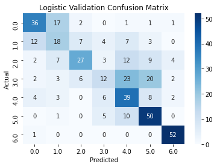

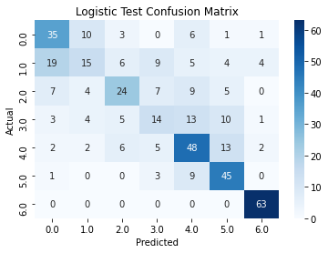

```python
def plot_confusion_matrix(y_true, y_pred, title='Confusion Matrix'):
    cm = confusion_matrix(y_true, y_pred)
    sns.heatmap(cm, annot=True, fmt='d', cmap='Blues',
                xticklabels=np.unique(y),
                yticklabels=np.unique(y))
    plt.title(title)
    plt.ylabel('Actual')
    plt.xlabel('Predicted')
    plt.show()

# Plot confusion matrices
plot_confusion_matrix(y_val, y_val_pred, title='Logistic Validation Confusion Matrix')
plot_confusion_matrix(y_test, y_test_pred, title='Logistic Test Confusion Matrix')
```

### Model 3: Random Forest Model

The third model chosen is a Random Forest model. A Random Forest model is a type of ensemble learning method used for classification and regression tasks. It works by creating a large number of decision trees during training and then aggregating their predictions to improve accuracy and control overfitting. Again, test, validation, and training sets were used to verify results.

```python
X = obesity_train_scale
y = obesity_test

X_train_val, X_test, y_train_val, y_test = train_test_split(X, y, test_size=0.2, random_state=42)
X_train, X_val, y_train, y_val = train_test_split(X_train_val, y_train_val, test_size=0.25, random_state=42)
```

Similar to the Logistic model above, Random Forest Models can benefit from scaling continuous data.

```python
scaler = StandardScaler()
numeric_columns = ['Age', 'Height']
X_train[numeric_columns] = scaler.fit_transform(X_train[numeric_columns])
X_val[numeric_columns] = scaler.transform(X_val[numeric_columns])
X_test[numeric_columns] = scaler.transform(X_test[numeric_columns])
```

```python
rf_model = RandomForestClassifier(random_state=42)
rf_model.fit(X_train, y_train)
```

```
RandomForestClassifier(random_state=42)
```

- The models produced by the Random Forest Modelling method are the best of the three models. By itself, the model evaluates to an efficient model as well.
- For precision, recall, and f1-score, all results are >0.6, which is showing that the model is doing a good job making predictions correctly.
- The consistency between the accuracy and classification reports for the test and validation sets are reassuring, but the difference between these and the training results shows that the model is potentially overfitted and there is room for improvement.

```python
y_val_pred = rf_model.predict(X_val)
y_train_pred = rf_model.predict(X_train_scaled)
train_accuracy = accuracy_score(y_train, y_train_pred)
print(f'Train Accuracy: {train_accuracy:.2f}')
print(f'Validation Accuracy: {accuracy_score(y_val, y_val_pred):.2f}')
print(classification_report(y_val, y_val_pred, zero_division=1))
```

```
Train Accuracy: 1.00
Validation Accuracy: 0.86
              precision    recall  f1-score   support

         0.0       0.93      0.91      0.92        58
         1.0       0.63      0.71      0.67        51
         2.0       0.89      0.78      0.83        64
         3.0       0.95      0.84      0.89        68
         4.0       0.78      0.87      0.82        62
         5.0       0.89      0.94      0.91        66
         6.0       0.98      0.98      0.98        53

    accuracy                           0.86       422
   macro avg       0.86      0.86      0.86       422
weighted avg       0.87      0.86      0.86       422
```

```python
y_test_pred = rf_model.predict(X_test)
y_train_pred = rf_model.predict(X_train_scaled)
print(f'Train Accuracy: {train_accuracy:.2f}')
print(f'Test Accuracy: {accuracy_score(y_test, y_test_pred):.2f}')
print(classification_report(y_test, y_test_pred))
```

```
Train Accuracy: 1.00
Test Accuracy: 0.85
              precision    recall  f1-score   support

         0.0       0.88      0.95      0.91        56
         1.0       0.65      0.74      0.69        62
         2.0       0.87      0.71      0.78        56
         3.0       0.79      0.76      0.78        50
         4.0       0.93      0.83      0.88        78
         5.0       0.85      0.95      0.89        58
         6.0       1.00      1.00      1.00        63

    accuracy                           0.85       423
   macro avg       0.85      0.85      0.85       423
weighted avg       0.86      0.85      0.85       423
```

- Again, the confusion matricies show with the darker center line that results are the best of the three. They have the greatest number of true positives and are fairly consistent with each other as well.

[figure not shown]

[figure not shown]

```python
def plot_confusion_matrix(y_true, y_pred, title='Confusion Matrix'):
    cm = confusion_matrix(y_true, y_pred)
    sns.heatmap(cm, annot=True, fmt='d', cmap='Blues',
                xticklabels=np.unique(y),
                yticklabels=np.unique(y))
    plt.title(title)
    plt.ylabel('Actual')
    plt.xlabel('Predicted')
    plt.show()

# Plot confusion matrices
plot_confusion_matrix(y_val, y_val_pred, title='Logistic Validation Confusion Matrix')
plot_confusion_matrix(y_test, y_test_pred, title='Logistic Test Confusion Matrix')
```

#### Hyperparameter Tuning

- The results above suggested potentiall overfitting, so hyperparameter tuning is necessary to optimize the model.
- n_estimators - This is the number of decision tree used inside the Random Forest. Results may change as this increases or decreases.
- max_depth - This controls the depth of the decision trees. Specifying 'None' allows them to grow without constraint, which poses the risk of overfitting and also the risk of capturing noise. Specifiying a max depth helps balance model complexity with generalization.
- min_samples_split - This parameter defines the minimum number of samples required to split an internal node, and can be used to prevent the model from learning overly specific patterns that may skew results.
- min_samples_leaf - This also helps prevent the model from learning overly specific patterns by specifying that a leaf must have more than a certain number of instances, which helps improve generalization.

```python
param_grid_rf = {
    'n_estimators': [100, 200, 300, 500],
    'max_depth': [None, 10, 20, 30, 40],
    'min_samples_split': [2, 5, 10],
    'min_samples_leaf': [1, 2, 4]
}

grid_search_rf = GridSearchCV(estimator=RandomForestClassifier(random_state=42),
                               param_grid=param_grid_rf,
                               cv=3,
                               scoring='accuracy')

grid_search_rf.fit(X_train, y_train)

print("Best parameters for Random Forest:", grid_search_rf.best_params_)
```

```
Best parameters for Random Forest: {'max_depth': None, 'min_samples_leaf': 1, 'min_samples_split': 2, 'n_estimators': 300}
```

#### Hyperparameter Tuning Results

Below the results of the hyperparameter search can be applied to analyze the restulting model improvement. After applying the optimal hyperparameters, the results are not much different. Validation and Test accuracy both improved 1%, and there are also minor improvements to precision, recall, and f1-score. After tuning, this implies this is the best model of the three for predicting weight class based on various lifestyle factors. Test accuracy of 86% implies the model is a good predictor of weight class.

```python
best_rf_model = grid_search_rf.best_estimator_

y_val_pred = best_rf_model.predict(X_val)
y_test_pred = best_rf_model.predict(X_test)

train_accuracy = accuracy_score(y_train, grid_search_rf.predict(X_train))  # Use the best model to predict on the train set
val_accuracy = accuracy_score(y_val, y_val_pred)
test_accuracy = accuracy_score(y_test, y_test_pred)

print(f"Training Accuracy: {train_accuracy:.2f}")
print(f"Validation Accuracy: {val_accuracy:.2f}")
print(f"Test Accuracy: {test_accuracy:.2f}")

print("Random Forest Classification Report (Test Set):")
print(classification_report(y_test, y_test_pred))

print("Random Forest Classification Report (Validation Set):")
print(classification_report(y_val, y_val_pred))
```

```
Training Accuracy: 1.00
Validation Accuracy: 0.87
Test Accuracy: 0.86
Random Forest Classification Report (Test Set):
              precision    recall  f1-score   support

         0.0       0.95      0.95      0.95        56
         1.0       0.66      0.79      0.72        62
         2.0       0.87      0.73      0.80        56
         3.0       0.83      0.76      0.79        50
         4.0       0.93      0.83      0.88        78
         5.0       0.82      0.95      0.88        58
         6.0       1.00      1.00      1.00        63

    accuracy                           0.86       423
   macro avg       0.87      0.86      0.86       423
weighted avg       0.87      0.86      0.86       423

Random Forest Classification Report (Validation Set):
              precision    recall  f1-score   support

         0.0       0.93      0.90      0.91        58
         1.0       0.65      0.71      0.68        51
         2.0       0.93      0.80      0.86        64
         3.0       0.92      0.84      0.88        68
         4.0       0.80      0.90      0.85        62
         5.0       0.90      0.97      0.93        66
         6.0       0.98      0.98      0.98        53

    accuracy                           0.87       422
   macro avg       0.87      0.87      0.87       422
weighted avg       0.88      0.87      0.87       422
```

#### Feature Importance

After choosing the best model, a useful tool is feature improtance to tell what factors can have the greatest pull on results. Based on the data and plot below, we can see that the biggest predictor is age, with the frequency of vegetables in meals as a close second. Motorbike and bike transports show to have the least influence on model results.

```
                                 Feature  Importance
0                                    Age    0.142714
2                               Veg_Freq    0.133966
1                                 Height    0.119671
7                              Tech_Time    0.091217
3                             Meals_PDay    0.084682
6                          Exercise_Freq    0.083919
5                             Water_PDay    0.076230
9                            Gender_Male    0.056340
8                                Alcohol    0.046615
4                                 Snacks    0.046177
10                          Fam_Hist_yes    0.044479
16  Transport_Type_Public_Transportation    0.029926
11                     High_Cal_Freq_yes    0.024822
13                         Cal_Count_yes    0.009393
17                Transport_Type_Walking    0.005737
12                             Smoke_yes    0.002920
14                   Transport_Type_Bike    0.000619
15              Transport_Type_Motorbike    0.000571
```

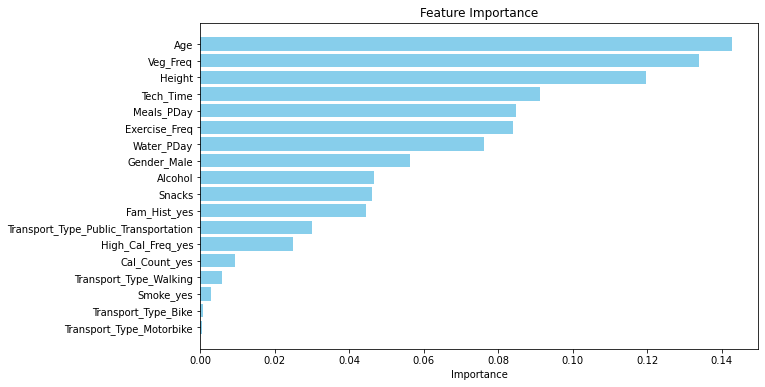

```python
importances = best_rf_model.feature_importances_

feature_names = X.columns

feature_importance_df = pd.DataFrame({
    'Feature': feature_names,
    'Importance': importances
})

feature_importance_df = feature_importance_df.sort_values(by='Importance', ascending=False)

print(feature_importance_df)

plt.figure(figsize=(10, 6))
plt.barh(feature_importance_df['Feature'], feature_importance_df['Importance'], color='skyblue')
plt.xlabel('Importance')
plt.title('Feature Importance')
plt.gca().invert_yaxis()  # Invert y-axis to show the most important features on top
plt.show()
```